# Question 1 - Part A

$$\begin{aligned}
R ^2 = 1 - (SSE/SST)\\
R ^2 = 1 - (1,319,082,976,816.139/12,694,825,780,588.189)\\
R ^2 = 1 - (.103907)\\
R ^2 = .896093
\end{aligned}$$

\

$$\begin{aligned}
RSD= \sqrt (SSE/degreesoffreedom) \\
RSD= \sqrt (1,319,082,976,816.139/1,480) \\
RSD= \sqrt (891272281.6)\\
RSD= 29854.18365
\end{aligned}$$

- The p-value associated with Cows is significant at .1% level and 5% level. When all other things are held constant, one unit increase in Cows is associated in 7773.716 unit change in Milk.

```r
result <- regress(DairyFarm, rvar = "Milk", evar = "Cows")
summary(result)
```

```
Linear regression (OLS)
Data     : DairyFarm
Response variable    : Milk
Explanatory variables: Cows
Null hyp.: the effect of Cows on Milk is zero
Alt. hyp.: the effect of Cows on Milk is not zero

             coefficient std.error t.value p.value
 (Intercept)  -40818.424  1707.993 -23.898  < .001 ***
 Cows           7773.716    68.809 112.976  < .001 ***

Signif. codes:  0 '***' 0.001 '**' 0.01 '*' 0.05 '.' 0.1 ' ' 1

R-squared: 0.896,  Adjusted R-squared: 0.896
F-statistic: 12763.49 df(1,1480), p.value < .001
Nr obs: 1,482
```

```r
result <- regress(DairyFarm, rvar = "Milk", evar = "Cows")
summary(result, sum_check = "sumsquares")
```

```
Linear regression (OLS)
Data     : DairyFarm
Response variable    : Milk
Explanatory variables: Cows
Null hyp.: the effect of Cows on Milk is zero
Alt. hyp.: the effect of Cows on Milk is not zero

             coefficient std.error t.value p.value
 (Intercept)  -40818.424  1707.993 -23.898  < .001 ***
 Cows           7773.716    68.809 112.976  < .001 ***

Signif. codes:  0 '***' 0.001 '**' 0.01 '*' 0.05 '.' 0.1 ' ' 1

R-squared: 0.896,  Adjusted R-squared: 0.896
F-statistic: 12763.49 df(1,1480), p.value < .001
Nr obs: 1,482

Sum of squares:
              df                     SS
Regression     1 11,375,742,803,772.051
Error      1,480  1,319,082,976,816.139
Total      1,481 12,694,825,780,588.189
```

- When Cows equals 30, the predicted units of Milk is **192393.058**

```r
pred <- predict(result, pred_data = DairyFarm, pred_cmd = "Cows=30")
print(pred, n = 10)
```

```
Linear regression (OLS)
Data                 : DairyFarm
Response variable    : Milk
Explanatory variables: Cows
Interval             : confidence
Prediction dataset   : DairyFarm
Customize command    : Cows = 30
Rows shown           : 10 of 1,482

   Cows Prediction       2.5%      97.5%      +/-
 30.000 192393.058 190536.625 194249.491 1856.433
 30.000 192393.058 190536.625 194249.491 1856.433
 30.000 192393.058 190536.625 194249.491 1856.433
 30.000 192393.058 190536.625 194249.491 1856.433
 30.000 192393.058 190536.625 194249.491 1856.433
 30.000 192393.058 190536.625 194249.491 1856.433
 30.000 192393.058 190536.625 194249.491 1856.433
 30.000 192393.058 190536.625 194249.491 1856.433
 30.000 192393.058 190536.625 194249.491 1856.433
 30.000 192393.058 190536.625 194249.491 1856.433
```

```r
DairyFarm <- store(DairyFarm, pred, name = "pred_reg")
```

- The mean of that prediction set is **192393.058**

```r
result <- explore(
  DairyFarm,
  vars = "pred_reg",
  fun = c("n_obs", "mean", "min", "max", "sd"),
  nr = 1
)
summary(result)
```

```
Explore
Data        : DairyFarm
Functions   : n_obs, mean, min, max, sd
Top         : Function

 variable n_obs        mean         min         max sd
 pred_reg 1,482 192,393.058 192,393.058 192,393.058  0
```

```r
# dtab(result) %>% render()
```

# Question 2

- The p-value associated with Cows is significant at .1% level and 5% level. When all other things are held constant, one unit increase in Cows is associated in 3666.474 unit change in Milk.

```r
result <- regress(
  DairyFarm,
  rvar = "Milk",
  evar = c("Cows", "Feed")
)
summary(result)
```

```
Linear regression (OLS)
Data     : DairyFarm
Response variable    : Milk
Explanatory variables: Cows, Feed
Null hyp.: the effect of x on Milk is zero
Alt. hyp.: the effect of x on Milk is not zero

             coefficient std.error t.value p.value
 (Intercept)  -12093.363  1307.483  -9.249  < .001 ***
 Cows           3666.474   104.549  35.069  < .001 ***
 Feed              1.072     0.025  43.637  < .001 ***

Signif. codes:  0 '***' 0.001 '**' 0.01 '*' 0.05 '.' 0.1 ' ' 1

R-squared: 0.955,  Adjusted R-squared: 0.955
F-statistic: 15540.19 df(2,1479), p.value < .001
Nr obs: 1,482
```

- When Cows equals 30 and Feed equals 57941.354, the predicted units of Milk is **160012.357**

```r
pred <- predict(result, pred_data = DairyFarm, pred_cmd = c("Cows=30", "Feed=57941.354"))
print(pred, n = 10)
```

```
Linear regression (OLS)
Data                 : DairyFarm
Response variable    : Milk
Explanatory variables: Cows, Feed
Interval             : confidence
Prediction dataset   : DairyFarm
Customize command    : Cows = 30; Feed = 57941.354
Rows shown           : 10 of 1,482

   Cows      Feed Prediction       2.5%      97.5%      +/-
 30.000 57941.354 160012.357 158108.049 161916.665 1904.308
 30.000 57941.354 160012.357 158108.049 161916.665 1904.308
 30.000 57941.354 160012.357 158108.049 161916.665 1904.308
 30.000 57941.354 160012.357 158108.049 161916.665 1904.308
 30.000 57941.354 160012.357 158108.049 161916.665 1904.308
 30.000 57941.354 160012.357 158108.049 161916.665 1904.308
 30.000 57941.354 160012.357 158108.049 161916.665 1904.308
 30.000 57941.354 160012.357 158108.049 161916.665 1904.308
 30.000 57941.354 160012.357 158108.049 161916.665 1904.308
 30.000 57941.354 160012.357 158108.049 161916.665 1904.308
```

```r
DairyFarm <- store(DairyFarm, pred, name = "pred_reg")
```

```r
result <- explore(
  DairyFarm,
  vars = "pred_reg2",
  fun = c("n_obs", "mean", "min", "max", "sd"),
  nr = 1
)
summary(result)
```

[output not shown]

```r
# dtab(result) %>% render()
```

# Question 3

$$\begin{aligned}
F = (R_2^2 - R_1^2)/(k2 -K_1) \\
----------------------- \\
(1-R_2^2)/(n-k-1)\\
\end{aligned}$$

Q1 SSE = 1319082976816.139

$$\begin{aligned}
R_1 ^2 = 1 - (SSE/SST)\\
R_1 ^2 = 1 - (1,319,082,976,816.139/12,694,825,780,588.189)\\
R_1^2 = 1 - (.103907)\\
R_1^2 = .896093
\end{aligned}$$

Q2 SSE = 576658649264.617

$$\begin{aligned}
R_2 ^2 = 1 - (SSE/SST)\\
R_2 ^2 = 1 - (576,658,649,264.617/12,694,825,780,588.189)\\
R_2^2 = 1 - (.0454247)\\
R_2^2 = .9545753
\end{aligned}$$

$$\begin{aligned}
F = (.9545753 - .896093)/(2 -1) \\
----------------------- \\
(1-.9545753)/(1482-2-1)\\
F = 1904.152
\end{aligned}$$

```r
result <- regress(
  DairyFarm,
  rvar = "Milk",
  evar = c("Cows", "Feed")
)
summary(result, sum_check = c("rmse", "sumsquares"), test_var = "Feed")
```

```
Linear regression (OLS)
Data     : DairyFarm
Response variable    : Milk
Explanatory variables: Cows, Feed
Null hyp.: the effect of x on Milk is zero
Alt. hyp.: the effect of x on Milk is not zero

             coefficient std.error t.value p.value
 (Intercept)  -12093.363  1307.483  -9.249  < .001 ***
 Cows           3666.474   104.549  35.069  < .001 ***
 Feed              1.072     0.025  43.637  < .001 ***

Signif. codes:  0 '***' 0.001 '**' 0.01 '*' 0.05 '.' 0.1 ' ' 1

R-squared: 0.955,  Adjusted R-squared: 0.955
F-statistic: 15540.19 df(2,1479), p.value < .001
Nr obs: 1,482

Prediction error (RMSE):  19725.83
Residual st.dev   (RSD):  19745.83

Sum of squares:
              df                     SS
Regression     2 12,118,167,131,323.572
Error      1,479    576,658,649,264.617
Total      1,481 12,694,825,780,588.189

Model 1: Milk ~ Cows
Model 2: Milk ~ Cows + Feed
R-squared, Model 1 vs 2: 0.896 0.955
F-statistic: 1904.152 df(1,1479), p.value < .001
```

```r
result <- prob_fdist(df1 = 1, df2 = 1479, ub = 1904.152, dec = 20)
summary(result)
```

```
Probability calculator
Distribution: F
Df 1        : 1
Df 2        : 1479
Mean        : 1.001354
Variance    : 2.009499
Lower bound : 0
Upper bound : 1904.152

P(X < 1904.152) = 1
P(X > 1904.152) = 0
```

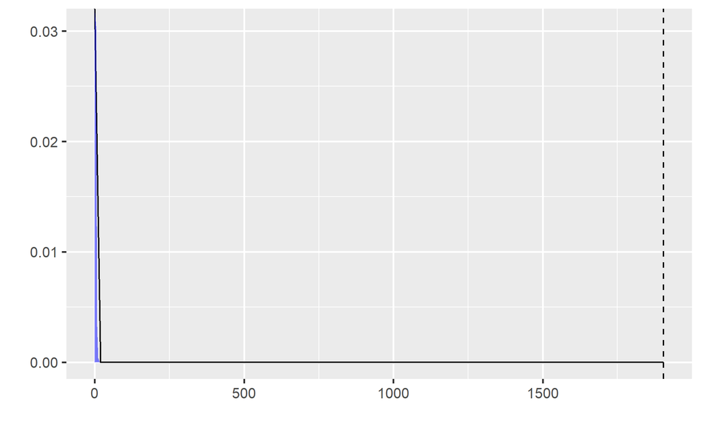

```r
plot(result)
```

# Question 4

- This model does suffer from multicollinearity as it has a VIF higher than 5. The VIF for Cows is 5.277 and the VIF for Feed is 5.277.

```r
result <- regress(
  DairyFarm,
  rvar = "Milk",
  evar = c("Cows", "Feed")
)
summary(result, sum_check = "vif")
```

```
Linear regression (OLS)
Data     : DairyFarm
Response variable    : Milk
Explanatory variables: Cows, Feed
Null hyp.: the effect of x on Milk is zero
Alt. hyp.: the effect of x on Milk is not zero

             coefficient std.error t.value p.value
 (Intercept)  -12093.363  1307.483  -9.249  < .001 ***
 Cows           3666.474   104.549  35.069  < .001 ***
 Feed              1.072     0.025  43.637  < .001 ***

Signif. codes:  0 '***' 0.001 '**' 0.01 '*' 0.05 '.' 0.1 ' ' 1

R-squared: 0.955,  Adjusted R-squared: 0.955
F-statistic: 15540.19 df(2,1479), p.value < .001
Nr obs: 1,482

Variance Inflation Factors
     Cows  Feed
VIF 5.277 5.277
Rsq 0.811 0.811
```

# Question 5

- We can see that from the Residuals vs Fitted graph a clear funnel shape, which indicates that the model does suffer from heteroscedasticity.

```r
result <- regress(
  DairyFarm,
  rvar = "Milk",
  evar = c("Cows", "Feed")
)
summary(result, sum_check = "vif")
```

```
Linear regression (OLS)
Data     : DairyFarm
Response variable    : Milk
Explanatory variables: Cows, Feed
Null hyp.: the effect of x on Milk is zero
Alt. hyp.: the effect of x on Milk is not zero

             coefficient std.error t.value p.value
 (Intercept)  -12093.363  1307.483  -9.249  < .001 ***
 Cows           3666.474   104.549  35.069  < .001 ***
 Feed              1.072     0.025  43.637  < .001 ***

Signif. codes:  0 '***' 0.001 '**' 0.01 '*' 0.05 '.' 0.1 ' ' 1

R-squared: 0.955,  Adjusted R-squared: 0.955
F-statistic: 15540.19 df(2,1479), p.value < .001
Nr obs: 1,482

Variance Inflation Factors
     Cows  Feed
VIF 5.277 5.277
Rsq 0.811 0.811
```

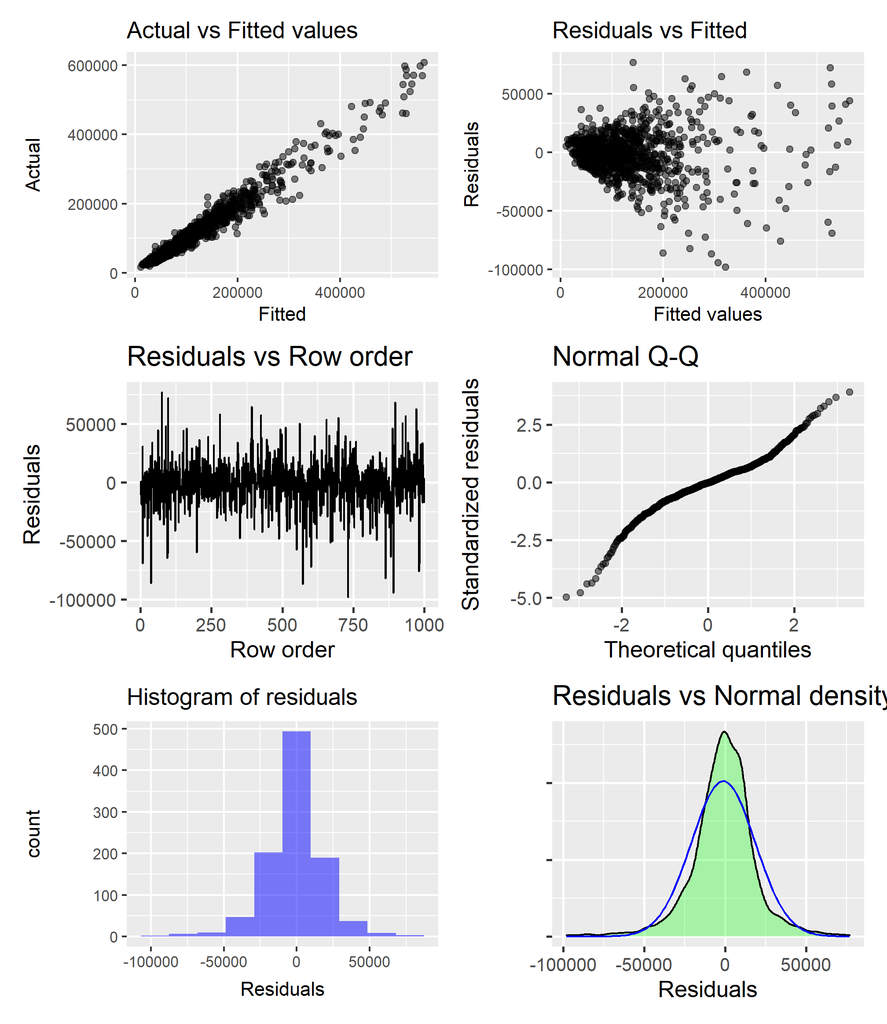

```r
plot(result, plots = "dashboard", nrobs = 1000, custom = FALSE)
```

# Question 6

- We can see from the above dashboard that the Normal Q-Q graph contains slight curves.
- The histogram of residuals vs normal density indicates that the distribution is slightly steeper than a normal distribution.
- These curves indicate that the distribution is not quite normal.

# Question 7

- The VIF for Cows in this model is 8.144

```r
result <- regress(
  DairyFarm,
  rvar = "Milk",
  evar = c("Cows", "Land", "Labor", "Feed")
)
summary(result, sum_check = "vif")
```

```
Linear regression (OLS)
Data     : DairyFarm
Response variable    : Milk
Explanatory variables: Cows, Land, Labor, Feed
Null hyp.: the effect of x on Milk is zero
Alt. hyp.: the effect of x on Milk is not zero

             coefficient std.error t.value p.value
 (Intercept)  -14066.087  1828.365  -7.693  < .001 ***
 Cows           3644.012   129.804  28.073  < .001 ***
 Land            -58.636   120.184  -0.488   0.626
 Labor          2031.408  1123.863   1.808   0.071 .
 Feed              1.069     0.025  42.371  < .001 ***

Signif. codes:  0 '***' 0.001 '**' 0.01 '*' 0.05 '.' 0.1 ' ' 1

R-squared: 0.955,  Adjusted R-squared: 0.955
F-statistic: 7779.617 df(4,1477), p.value < .001
Nr obs: 1,482

Variance Inflation Factors
     Cows  Feed  Land Labor
VIF 8.144 5.574 2.092 1.468
Rsq 0.877 0.821 0.522 0.319
```

# Question 8

- The coefficient for Labor is not statistically significant at the 5% level.

```r
result <- prob_tdist(df = 1481, lb = -1.808, ub = 1.808, dec = 5)
summary(result)
```

```
Probability calculator
Distribution: t
Df          : 1481
Mean        : 0
St. dev     : 1.00135
Lower bound : -1.808
Upper bound : 1.808

P(X < -1.808) = 0.0354
P(X > -1.808) = 0.9646
P(X < 1.808) = 0.9646
P(X > 1.808) = 0.0354
P(-1.808 < X < 1.808)     = 0.92919
1 - P(-1.808 < X < 1.808) = 0.07081
```

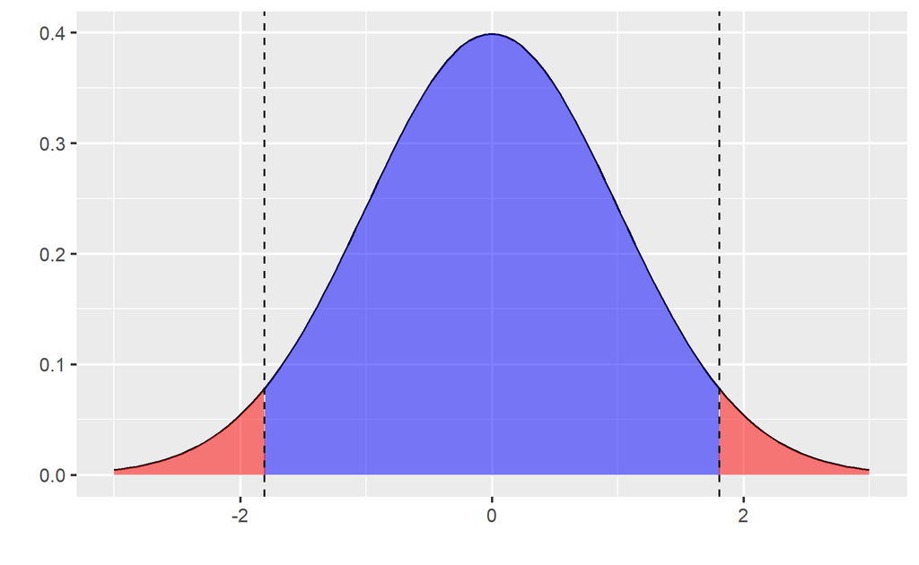

```r
plot(result)
```

# Question 9

- The mean for Milk_ln is **11.577**

```r
result <- explore(
  DairyFarm,
  vars = "Milk_ln",
  fun = "mean",
  nr = 1
)
summary(result)
```

```
Explore
Data        : DairyFarm
Functions   : mean
Top         : Function

 variable   mean
  Milk_ln 11.577
```

```r
# dtab(result) %>% render()
```

- The correlation coefficient for Milk_ln and Land_ln is .63

```r
result <- correlation(
  DairyFarm,
  vars = c("Milk_ln", "Land_ln")
)
summary(result)
```

```
Correlation
Data        : DairyFarm
Method      : Pearson
Variables   : Milk_ln, Land_ln
Null hyp.   : variables x and y are not correlated
Alt. hyp.   : variables x and y are correlated

Correlation matrix:
        Milk_ln
Land_ln 0.63

p.values:
        Milk_ln
Land_ln 0.00
```

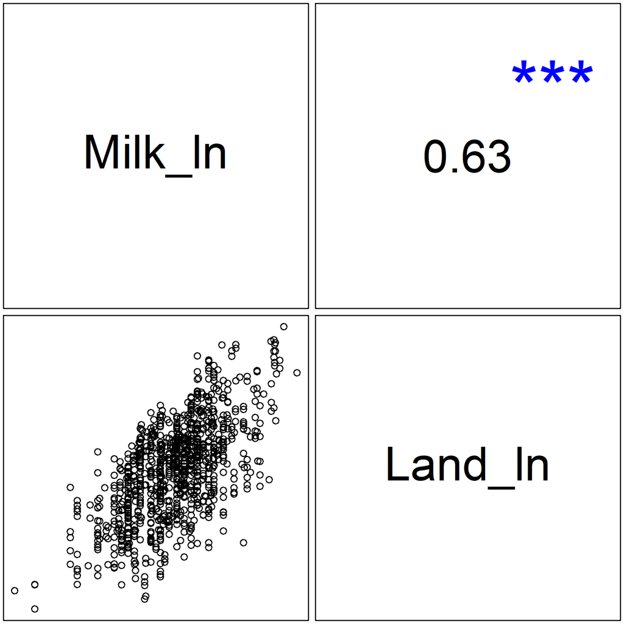

```r
plot(result, nrobs = 1000)
```

# Question 10

```r
result <- regress(
  DairyFarm,
  rvar = "Milk_ln",
  evar = c("Year", "Cows_ln", "Land_ln", "Labor_ln", "Feed_ln")
)
summary(result)
```

```
Linear regression (OLS)
Data     : DairyFarm
Response variable    : Milk_ln
Explanatory variables: Year, Cows_ln, Land_ln, Labor_ln, Feed_ln
Null hyp.: the effect of x on Milk_ln is zero
Alt. hyp.: the effect of x on Milk_ln is not zero

             coefficient std.error t.value p.value
 (Intercept)       4.946     0.078  63.143  < .001 ***
 Year|94           0.017     0.013   1.344   0.179
 Year|95           0.031     0.013   2.433   0.015 *
 Year|96           0.029     0.013   2.263   0.024 *
 Year|97           0.024     0.013   1.894   0.058 .
 Year|98           0.034     0.013   2.649   0.008 **
 Cows_ln           0.601     0.020  30.577  < .001 ***
 Land_ln           0.024     0.011   2.102   0.036 *
 Labor_ln          0.027     0.013   2.081   0.038 *
 Feed_ln           0.444     0.011  40.113  < .001 ***

Signif. codes:  0 '***' 0.001 '**' 0.01 '*' 0.05 '.' 0.1 ' ' 1

R-squared: 0.953,  Adjusted R-squared: 0.953
F-statistic: 3305.108 df(9,1472), p.value < .001
Nr obs: 1,482
```

# Question 11

- The mean of the predicted value of Milk_ln is **11.843**
- **11.843** translates to **139107.1808** liters of Milk.

```r
pred <- predict(
  result,
  pred_data = DairyFarm,
  pred_cmd = c(
    "Cows_ln=3.401", "Year='98'", "Land_ln=2.461", "Labor_ln=0.457",
    "Feed_ln=10.685\n"
  )
)
print(pred, n = 10)
```

```
Linear regression (OLS)
Data                 : DairyFarm
Response variable    : Milk_ln
Explanatory variables: Year, Cows_ln, Land_ln, Labor_ln, Feed_ln
Interval             : confidence
Prediction dataset   : DairyFarm
Customize command    : Cows_ln = 3.401; Year = '98'; Land_ln = 2.461; Labor_ln = 0.457; Feed_ln = 10.685
Rows shown           : 10 of 1,482

 Year Cows_ln Land_ln Labor_ln Feed_ln Prediction   2.5%  97.5%   +/-
   98   3.401   2.461    0.457  10.685     11.843 11.818 11.867 0.025
   98   3.401   2.461    0.457  10.685     11.843 11.818 11.867 0.025
   98   3.401   2.461    0.457  10.685     11.843 11.818 11.867 0.025
   98   3.401   2.461    0.457  10.685     11.843 11.818 11.867 0.025
   98   3.401   2.461    0.457  10.685     11.843 11.818 11.867 0.025
   98   3.401   2.461    0.457  10.685     11.843 11.818 11.867 0.025
   98   3.401   2.461    0.457  10.685     11.843 11.818 11.867 0.025
   98   3.401   2.461    0.457  10.685     11.843 11.818 11.867 0.025
   98   3.401   2.461    0.457  10.685     11.843 11.818 11.867 0.025
   98   3.401   2.461    0.457  10.685     11.843 11.818 11.867 0.025
```

```r
DairyFarm <- store(DairyFarm, pred, name = "pred_reg2")
```

# Question 12

- This model does suffer form multicollinearity as Cows_ln is 6.947 and Feed_ln is 5.346. Both of these values are greater than 5.

```r
result <- regress(
  DairyFarm,
  rvar = "Milk_ln",
  evar = c("Year", "Cows_ln", "Land_ln", "Labor_ln", "Feed_ln")
)
summary(result, sum_check = "vif")
```

```
Linear regression (OLS)
Data     : DairyFarm
Response variable    : Milk_ln
Explanatory variables: Year, Cows_ln, Land_ln, Labor_ln, Feed_ln
Null hyp.: the effect of x on Milk_ln is zero
Alt. hyp.: the effect of x on Milk_ln is not zero

             coefficient std.error t.value p.value
 (Intercept)       4.946     0.078  63.143  < .001 ***
 Year|94           0.017     0.013   1.344   0.179
 Year|95           0.031     0.013   2.433   0.015 *
 Year|96           0.029     0.013   2.263   0.024 *
 Year|97           0.024     0.013   1.894   0.058 .
 Year|98           0.034     0.013   2.649   0.008 **
 Cows_ln           0.601     0.020  30.577  < .001 ***
 Land_ln           0.024     0.011   2.102   0.036 *
 Labor_ln          0.027     0.013   2.081   0.038 *
 Feed_ln           0.444     0.011  40.113  < .001 ***

Signif. codes:  0 '***' 0.001 '**' 0.01 '*' 0.05 '.' 0.1 ' ' 1

R-squared: 0.953,  Adjusted R-squared: 0.953
F-statistic: 3305.108 df(9,1472), p.value < .001
Nr obs: 1,482

Variance Inflation Factors
    Cows_ln Feed_ln Land_ln Labor_ln  Year
VIF   6.947   5.346   1.972    1.522 1.094
Rsq   0.856   0.813   0.493    0.343 0.086
```

# Question 13

- This model does not suffer from heteroscedasticity as seen in the residuals vs fitted plot below.

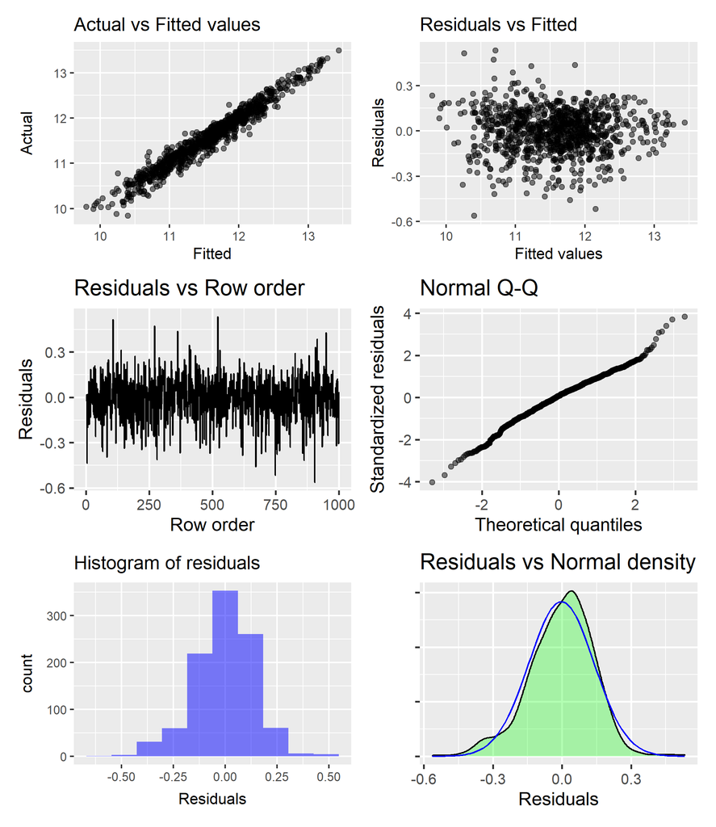

```r
plot(result, plots = "dashboard", nrobs = 1000, custom = FALSE)
```

# Question 14

- Generally the model follows a normal distribution; however, there is a slight skew.
- There is a slight kink in the Q-Q plot above, which indicates that there is slight deviation from a normal distribution.
- This model has a generally normal distribution as seen in the Residuals vs Normal density graph above. There is a slight skew on lower end around -.3.

# Question 15

```r
result <- regress(
  DairyFarm,
  rvar = "Milk_ln",
  evar = c("Year", "Cows_ln", "Land_ln", "Labor_ln", "Feed_ln"),
  int = c("Year:Cows_ln", "Cows_ln:Labor_ln")
)
summary(result)
```

```
Linear regression (OLS)
Data     : DairyFarm
Response variable    : Milk_ln
Explanatory variables: Year, Cows_ln, Land_ln, Labor_ln, Feed_ln
Null hyp.: the effect of x on Milk_ln is zero
Alt. hyp.: the effect of x on Milk_ln is not zero

                  coefficient std.error t.value p.value
 (Intercept)            5.153     0.099  51.806  < .001 ***
 Year|94               -0.028     0.079  -0.360   0.719
 Year|95               -0.030     0.079  -0.385   0.701
 Year|96               -0.133     0.080  -1.674   0.094 .
 Year|97               -0.097     0.080  -1.222   0.222
 Year|98               -0.075     0.078  -0.959   0.338
 Cows_ln                0.549     0.027  20.317  < .001 ***
 Land_ln                0.020     0.011   1.796   0.073 .
 Labor_ln              -0.186     0.063  -2.952   0.003 **
 Feed_ln                0.439     0.011  39.565  < .001 ***
 Year|94:Cows_ln        0.016     0.027   0.594   0.553
 Year|95:Cows_ln        0.022     0.027   0.808   0.419
 Year|96:Cows_ln        0.055     0.027   2.068   0.039 *
 Year|97:Cows_ln        0.042     0.027   1.565   0.118
 Year|98:Cows_ln        0.037     0.026   1.431   0.153
 Cows_ln:Labor_ln       0.072     0.021   3.472  < .001 ***

Signif. codes:  0 '***' 0.001 '**' 0.01 '*' 0.05 '.' 0.1 ' ' 1

R-squared: 0.953,  Adjusted R-squared: 0.953
F-statistic: 2001.726 df(15,1466), p.value < .001
Nr obs: 1,482
```

# Question 16

- Holding all else constant, 1% increase in Cows for Year93 with 1 laborer leads to .551% (=(EXP(0.549x0.01)-1)x 100) increase in Milk.
- Holding all else constant, 1% increase in Cows for Year93 with 10 laborers leads to .717% (=(EXP(0.714x0.01)-1)x 100) increase in Milk.

# Question 1 - Part B

- Yes this model does suffer from multicollinearity as Vehicle_Class (39.901), Monthly_Premium_Auto (38.866), Coverage (7.726), and Total_Claim_Amount (5.242) all have VIF numbers greater than 5.
- The log-liklihood of this model is **-240.018**.

```r
result <- logistic(
  InsuranceRenewalTrain,
  rvar = "Response",
  evar = c(
    "State", "Coverage",
    "Location_Code", "Monthly_Premium_Auto",
    "Months_Since_Last_Claim",
    "Months_Since_Policy_Inception",
    "Number_of_Open_Complaints",
    "Number_of_Policies",
    "Policy", "Sales_Channel",
    "Total_Claim_Amount",
    "Vehicle_Class", "Vehicle_Size",
    "Renew_Offer"
  ),
  lev = "1"
)
summary(result, sum_check = "vif")
```

```
Logistic regression (GLM)
Data                 : InsuranceRenewalTrain
Response variable    : Response
Level                : 1 in Response
Explanatory variables: State, Coverage, Location_Code, Monthly_Premium_Auto, Months_Since_Last_Claim, Months_Since_Policy_Inception, Number_of_Open_Complaints, Number_of_Policies, Policy, Sales_Channel, Total_Claim_Amount, Vehicle_Class, Vehicle_Size, Renew_Offer
Null hyp.: there is no effect of x on Response
Alt. hyp.: there is an effect of x on Response

                                   OR      OR% coefficient std.error z.value p.value
 (Intercept)                                        -3.890     1.556  -2.499   0.012 *
 State|California               0.948    -5.2%      -0.054     0.360  -0.149   0.881
 State|Nevada                   0.831   -16.9%      -0.185     0.507  -0.365   0.715
 State|Oregon                   0.797   -20.3%      -0.227     0.368  -0.618   0.537
 State|Washington               0.912    -8.8%      -0.092     0.497  -0.185   0.854
 Coverage|Extended              0.997    -0.3%      -0.003     0.482  -0.007   0.995
 Coverage|Premium               1.270    27.0%       0.239     0.910   0.263   0.793
 Location_Code|Suburban        41.252 4,025.2%       3.720     0.657   5.663  < .001 ***
 Location_Code|Urban            2.950   195.0%       1.082     0.720   1.503   0.133
 Monthly_Premium_Auto           1.011     1.1%       0.011     0.018   0.569   0.569
 Months_Since_Last_Claim        0.973    -2.7%      -0.027     0.013  -2.155   0.031 *
 Months_Since_Policy_Inception  0.996    -0.4%      -0.004     0.004  -0.811   0.417
 Number_of_Open_Complaints      0.987    -1.3%      -0.014     0.136  -0.099   0.921
 Number_of_Policies             0.890   -11.0%      -0.117     0.055  -2.132   0.033 *
 Policy|Corporate L2            1.372    37.2%       0.316     0.828   0.382   0.702
 Policy|Corporate L3            1.301    30.1%       0.263     0.755   0.348   0.728
 Policy|Personal L1             1.238    23.8%       0.213     0.732   0.291   0.771
 Policy|Personal L2             0.564   -43.6%      -0.573     0.747  -0.767   0.443
 Policy|Personal L3             1.283    28.3%       0.249     0.698   0.357   0.721
 Policy|Special L1              2.043   104.3%       0.714     1.189   0.601   0.548
 Policy|Special L2              0.000  -100.0%     -15.011   703.921  -0.021   0.983
 Policy|Special L3              5.691   469.1%       1.739     0.973   1.787   0.074 .
 Sales_Channel|Branch           0.593   -40.7%      -0.522     0.303  -1.721   0.085 .
 Sales_Channel|Call Center      0.301   -69.9%      -1.202     0.429  -2.805   0.005 **
 Sales_Channel|Web              1.899    89.9%       0.641     0.380   1.688   0.091 .
 Total_Claim_Amount             0.994    -0.6%      -0.006     0.001  -4.821  < .001 ***
 Vehicle_Class|Luxury Car      18.706 1,770.6%       2.929     2.499   1.172   0.241
 Vehicle_Class|Luxury SUV      22.579 2,157.9%       3.117     2.666   1.169   0.242
 Vehicle_Class|Sports Car       1.458    45.8%       0.377     1.010   0.374   0.709
 Vehicle_Class|SUV              1.868    86.8%       0.625     0.851   0.734   0.463
 Vehicle_Class|Two-Door Car     0.733   -26.7%      -0.310     0.347  -0.892   0.372
```

[output cut: 12 more lines]

```
                                 VIF   Rsq
Vehicle_Class                 39.901 0.975
Monthly_Premium_Auto          38.866 0.974
Coverage                       7.726 0.871
Total_Claim_Amount             5.242 0.809
Location_Code                  3.112 0.679
Policy                         1.507 0.336
Sales_Channel                  1.376 0.273
State                          1.258 0.205
Renew_Offer                    1.168 0.144
Vehicle_Size                   1.165 0.141
Number_of_Policies             1.103 0.093
Months_Since_Policy_Inception  1.085 0.078
Months_Since_Last_Claim        1.072 0.067
Number_of_Open_Complaints      1.067 0.063
```

# Question 2

- The coefficient on Number_of_Policies is -.117. Holding all other variables constant, 1 unit change in Number_of_Policies will lead to an decrease in odds of the customer responding by 11.04% ([=EXP(-.117)-1]x100).
- The coefficient on Renew_Offer is 2.247. Holding all other variables constant, if the customer does Renew_Offer it will lead to an increase in odds of the customer responding by 845.93% ([=EXP(2.247)-1]x100).
- The baseline for Renew_Offer appears to be 0, or they do not renew their offer.

# Question 3

- The log-liklihood of this model is **-242.458**.

```r
result <- logistic(
  InsuranceRenewalTrain,
  rvar = "Response",
  evar = c(
    "State", "Coverage",
    "Location_Code", "Monthly_Premium_Auto",
    "Months_Since_Last_Claim",
    "Months_Since_Policy_Inception",
    "Number_of_Open_Complaints",
    "Policy", "Sales_Channel",
    "Total_Claim_Amount",
    "Vehicle_Class", "Vehicle_Size",
    "Renew_Offer"
  ),
  lev = "1"
)
summary(result, sum_check = "vif")
```

```
Logistic regression (GLM)
Data                 : InsuranceRenewalTrain
Response variable    : Response
Level                : 1 in Response
Explanatory variables: State, Coverage, Location_Code, Monthly_Premium_Auto, Months_Since_Last_Claim, Months_Since_Policy_Inception, Number_of_Open_Complaints, Policy, Sales_Channel, Total_Claim_Amount, Vehicle_Class, Vehicle_Size, Renew_Offer
Null hyp.: there is no effect of x on Response
Alt. hyp.: there is an effect of x on Response

                                   OR      OR% coefficient std.error z.value p.value
 (Intercept)                                        -4.109     1.553  -2.646   0.008 **
 State|California               0.980    -2.0%      -0.020     0.358  -0.056   0.956
 State|Nevada                   0.868   -13.2%      -0.142     0.504  -0.282   0.778
 State|Oregon                   0.850   -15.0%      -0.162     0.364  -0.446   0.656
 State|Washington               1.022     2.2%       0.022     0.489   0.045   0.964
 Coverage|Extended              1.083     8.3%       0.080     0.477   0.167   0.867
 Coverage|Premium               1.546    54.6%       0.435     0.903   0.482   0.630
 Location_Code|Suburban        38.623 3,762.3%       3.654     0.654   5.588  < .001 ***
 Location_Code|Urban            2.840   184.0%       1.044     0.717   1.456   0.145
 Monthly_Premium_Auto           1.007     0.7%       0.007     0.018   0.401   0.688
 Months_Since_Last_Claim        0.974    -2.6%      -0.027     0.013  -2.142   0.032 *
 Months_Since_Policy_Inception  0.997    -0.3%      -0.003     0.004  -0.585   0.558
 Number_of_Open_Complaints      1.008     0.8%       0.008     0.134   0.062   0.951
 Policy|Corporate L2            1.443    44.3%       0.367     0.820   0.448   0.654
 Policy|Corporate L3            1.345    34.5%       0.296     0.748   0.397   0.692
 Policy|Personal L1             1.271    27.1%       0.239     0.724   0.330   0.741
 Policy|Personal L2             0.603   -39.7%      -0.505     0.737  -0.685   0.493
 Policy|Personal L3             1.327    32.7%       0.283     0.689   0.411   0.681
 Policy|Special L1              2.577   157.7%       0.947     1.176   0.805   0.421
 Policy|Special L2              0.000  -100.0%     -15.026   703.004  -0.021   0.983
 Policy|Special L3              4.967   396.7%       1.603     0.976   1.642   0.101
 Sales_Channel|Branch           0.599   -40.1%      -0.513     0.301  -1.702   0.089 .
 Sales_Channel|Call Center      0.293   -70.7%      -1.228     0.426  -2.887   0.004 **
 Sales_Channel|Web              1.777    77.7%       0.575     0.378   1.521   0.128
 Total_Claim_Amount             0.995    -0.5%      -0.005     0.001  -4.718  < .001 ***
 Vehicle_Class|Luxury Car      25.343 2,434.3%       3.233     2.499   1.294   0.196
 Vehicle_Class|Luxury SUV      35.432 3,443.2%       3.568     2.653   1.345   0.179
 Vehicle_Class|Sports Car       1.517    51.7%       0.417     1.009   0.413   0.680
 Vehicle_Class|SUV              2.077   107.7%       0.731     0.851   0.859   0.390
 Vehicle_Class|Two-Door Car     0.769   -23.1%      -0.263     0.345  -0.761   0.447
 Vehicle_Size|Medsize           0.583   -41.7%      -0.540     0.407  -1.327   0.185
```

[output cut: 10 more lines]

```
Variance Inflation Factors
                                 VIF   Rsq
Vehicle_Class                 39.520 0.975
Monthly_Premium_Auto          38.645 0.974
Coverage                       7.680 0.870
Total_Claim_Amount             5.189 0.807
Location_Code                  3.115 0.679
Policy                         1.445 0.308
Sales_Channel                  1.350 0.259
State                          1.229 0.186
Vehicle_Size                   1.153 0.133
Renew_Offer                    1.150 0.130
Months_Since_Policy_Inception  1.070 0.065
Months_Since_Last_Claim        1.068 0.064
Number_of_Open_Complaints      1.060 0.056
```

# Question 4

- The larger model should be used.
- *The p-value in the chi-squared prediction is .02717 and it is significant at the 5% level.

$$\begin{aligned}
Deviance = -2\times ((-242.458)-(-240.018))\\
Deviance = -2\times (-2.44)\\
Deviance = 4.88\\
\end{aligned}$$

```r
result <- prob_chisq(df = 1, ub = 4.88, dec = 5)
summary(result)
```

```
Probability calculator
Distribution: Chi-squared
Df          : 1
Mean        : 1
Variance    : 2
Lower bound : 0
Upper bound : 4.88

P(X < 4.88) = 0.97283
P(X > 4.88) = 0.02717
```

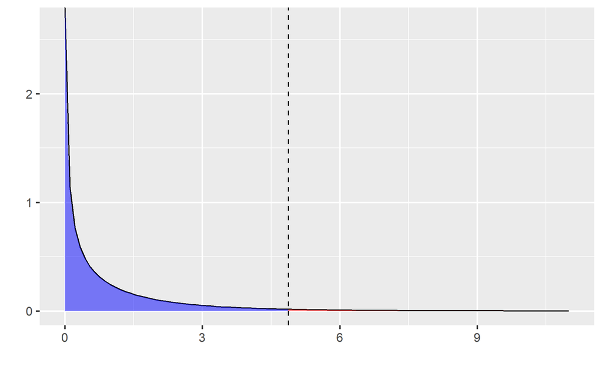

```r
plot(result)
```

# Question 5

```r
result <- explore(
  InsuranceRenewalTrain,
  vars = "pred_resp_prob",
  fun = "mean",
  data_filter = "Renew_Offer==0",
  nr = 1
)
```

[output not shown]

```r
summary(result)
```

[output not shown]

```r
# dtab(result) %>% render()
```

```r
result <- explore(
  InsuranceRenewalTrain,
  vars = "pred_resp_prob",
  fun = "mean",
  data_filter = "Renew_Offer==1",
  nr = 1
)
```

[output not shown]

```r
summary(result)
```

[output not shown]

```r
# dtab(result) %>% render()
```

```r
result <- explore(
  InsuranceRenewalTrain,
  vars = "Odds",
  fun = "mean",
  nr = 1
)
```

[output not shown]

```r
summary(result)
```

[output not shown]

```r
# dtab(result) %>% render()
```

```r
result <- explore(
  InsuranceRenewalTrain,
  vars = "LogLikelihood",
  fun = "sum",
  nr = 1
)
```

[output not shown]

```r
summary(result)
```

[output not shown]

```r
# dtab(result) %>% render()
```

# Question 6

```r
visualize(
  InsuranceRenewalTrain,
  xvar = "pred_resp_prob_dec",
  yvar = "Response",
  type = "bar",
  custom = FALSE
)
```

[output not shown]

```r
result <- explore(
  InsuranceRenewalTrain,
  vars = "Response",
  byvar = "pred_resp_prob_dec",
  fun = "mean",
  nr = 10
)
```

[output not shown]

```r
summary(result)
```

[output not shown]

```r
# dtab(result) %>% render()
```

# Question 7

```r
result <- explore(
  InsuranceRenewalTrain,
  vars = "pred_resp_prob",
  byvar = c("Response", "pred_resp_prob_rc"),
  fun = "n_obs",
  nr = 4
)
```

[output not shown]

```r
summary(result)
```

[output not shown]

```r
# dtab(result) %>% render()
```

```r
result <- explore(
  InsuranceRenewalTrain,
  vars = "pred_resp_prob",
  byvar = c("Response", "pred_resp_prob_rcpt3"),
  fun = "n_obs",
  nr = 4
)
```

[output not shown]

```r
summary(result)
```

[output not shown]

```r
# dtab(result) %>% render()
```

# Question 8